# Optimal Treatment Analysis

## Outcome Variable

**Outcome Variable:** whz

## Predictor Variables

**Intervention Variable:** parity

**Adjustment Set:**

- arm
- W_mage
- meducyrs
- feducyrs
- hhwealth_quart
- W_mhtcm
- W_mwtkg
- W_mbmi
- vagbrth
- W_nrooms
- impsan
- delta_W_mage
- delta_meducyrs
- delta_feducyrs
- delta_hhwealth_quart
- delta_W_mhtcm
- delta_W_mwtkg
- delta_W_mbmi
- delta_vagbrth
- delta_W_nrooms
- delta_impsan

## Stratifying Variables

The analysis was stratified on these variable(s):

- agecat
- studyid
- country

## Data Summary

| agecat | studyid | country | parity | n_cell | n |
| --- | --- | --- | --- | --- | --- |
| Birth | ki1000304b-SAS-CompFeed | INDIA | 1 | 304 | 1103 |
| Birth | ki1000304b-SAS-CompFeed | INDIA | 2 | 258 | 1103 |
| Birth | ki1000304b-SAS-CompFeed | INDIA | 3+ | 541 | 1103 |
| Birth | ki1017093b-PROVIDE | BANGLADESH | 1 | 202 | 532 |
| Birth | ki1017093b-PROVIDE | BANGLADESH | 2 | 182 | 532 |
| Birth | ki1017093b-PROVIDE | BANGLADESH | 3+ | 148 | 532 |
| Birth | ki1101329-Keneba | GAMBIA | 1 | 146 | 1338 |
| Birth | ki1101329-Keneba | GAMBIA | 2 | 142 | 1338 |
| Birth | ki1101329-Keneba | GAMBIA | 3+ | 1050 | 1338 |
| Birth | ki1113344-GMS-Nepal | NEPAL | 1 | 185 | 641 |
| Birth | ki1113344-GMS-Nepal | NEPAL | 2 | 169 | 641 |
| Birth | ki1113344-GMS-Nepal | NEPAL | 3+ | 287 | 641 |
| Birth | ki1126311-ZVITAMBO | ZIMBABWE | 1 | 5561 | 12916 |
| Birth | ki1126311-ZVITAMBO | ZIMBABWE | 2 | 3882 | 12916 |
| Birth | ki1126311-ZVITAMBO | ZIMBABWE | 3+ | 3473 | 12916 |
| Birth | ki1135781-COHORTS | GUATEMALA | 1 | 94 | 756 |
| Birth | ki1135781-COHORTS | GUATEMALA | 2 | 118 | 756 |
| Birth | ki1135781-COHORTS | GUATEMALA | 3+ | 544 | 756 |
| Birth | ki1135781-COHORTS | INDIA | 1 | 641 | 3855 |
| Birth | ki1135781-COHORTS | INDIA | 2 | 982 | 3855 |
| Birth | ki1135781-COHORTS | INDIA | 3+ | 2232 | 3855 |
| Birth | ki1135781-COHORTS | PHILIPPINES | 1 | 640 | 2899 |
| Birth | ki1135781-COHORTS | PHILIPPINES | 2 | 657 | 2899 |
| Birth | ki1135781-COHORTS | PHILIPPINES | 3+ | 1602 | 2899 |
| Birth | kiGH5241-JiVitA-3 | BANGLADESH | 1 | 5520 | 18014 |
| Birth | kiGH5241-JiVitA-3 | BANGLADESH | 2 | 6303 | 18014 |
| Birth | kiGH5241-JiVitA-3 | BANGLADESH | 3+ | 6191 | 18014 |
| 6 months | ki1000304b-SAS-CompFeed | INDIA | 1 | 392 | 1334 |
| 6 months | ki1000304b-SAS-CompFeed | INDIA | 2 | 302 | 1334 |
| 6 months | ki1000304b-SAS-CompFeed | INDIA | 3+ | 640 | 1334 |

[output cut: 57 more lines]

The following strata were considered:

- agecat: 24 months, studyid: ki1017093b-PROVIDE, country: BANGLADESH
- agecat: 24 months, studyid: ki1066203-TanzaniaChild2, country: TANZANIA, UNITED REPUBLIC OF
- agecat: 24 months, studyid: ki1101329-Keneba, country: GAMBIA
- agecat: 24 months, studyid: ki1113344-GMS-Nepal, country: NEPAL
- agecat: 24 months, studyid: ki1126311-ZVITAMBO, country: ZIMBABWE
- agecat: 24 months, studyid: ki1135781-COHORTS, country: GUATEMALA
- agecat: 24 months, studyid: ki1135781-COHORTS, country: INDIA
- agecat: 24 months, studyid: ki1135781-COHORTS, country: PHILIPPINES
- agecat: 24 months, studyid: kiGH5241-JiVitA-3, country: BANGLADESH
- agecat: 6 months, studyid: ki1000304b-SAS-CompFeed, country: INDIA
- agecat: 6 months, studyid: ki1000304b-SAS-FoodSuppl, country: INDIA
- agecat: 6 months, studyid: ki1017093b-PROVIDE, country: BANGLADESH
- agecat: 6 months, studyid: ki1066203-TanzaniaChild2, country: TANZANIA, UNITED REPUBLIC OF
- agecat: 6 months, studyid: ki1101329-Keneba, country: GAMBIA
- agecat: 6 months, studyid: ki1113344-GMS-Nepal, country: NEPAL
- agecat: 6 months, studyid: ki1126311-ZVITAMBO, country: ZIMBABWE
- agecat: 6 months, studyid: ki1135781-COHORTS, country: GUATEMALA
- agecat: 6 months, studyid: ki1135781-COHORTS, country: INDIA
- agecat: 6 months, studyid: ki1135781-COHORTS, country: PHILIPPINES
- agecat: 6 months, studyid: kiGH5241-JiVitA-3, country: BANGLADESH
- agecat: Birth, studyid: ki1000304b-SAS-CompFeed, country: INDIA
- agecat: Birth, studyid: ki1017093b-PROVIDE, country: BANGLADESH
- agecat: Birth, studyid: ki1101329-Keneba, country: GAMBIA
- agecat: Birth, studyid: ki1113344-GMS-Nepal, country: NEPAL
- agecat: Birth, studyid: ki1126311-ZVITAMBO, country: ZIMBABWE
- agecat: Birth, studyid: ki1135781-COHORTS, country: GUATEMALA
- agecat: Birth, studyid: ki1135781-COHORTS, country: INDIA
- agecat: Birth, studyid: ki1135781-COHORTS, country: PHILIPPINES
- agecat: Birth, studyid: kiGH5241-JiVitA-3, country: BANGLADESH

### Dropped Strata

Some strata were dropped due to rare outcomes:

- agecat: 24 months, studyid: ki1066203-TanzaniaChild2, country: TANZANIA, UNITED REPUBLIC OF

## Methods Detail

We’re interested in the causal parameters $E[Y_a]$ for all values of $a \in \mathcal{A}$. These parameters represent the mean outcome if, possibly contrary to fact, we intervened to set all units to have $A=a$. Under the randomization and positivity assumptions, these are identified by the statistical parameters $\psi_a=E_W[E_{Y|A,W}(Y|A=a,W)]$. In addition, we’re interested in the mean of $Y$, $E[Y]$ under no intervention (the observed mean). We will estimate these parameters by using SuperLearner to fit the relevant likelihood factors – $E_{Y|A,W}(Y|A=a,W)$ and $p(A=a|W)$, and then updating our likelihood fit using a joint TMLE.

For unadjusted analyses ($W=\{\}$), initial likelihoods were estimated using Lrnr_glm to estimate the simple $E(Y|A)$ and Lrnr_mean to estimate $p(A)$. For adjusted analyses, a small library containing Lrnr_glmnet, Lrnr_xgboost, and Lrnr_mean was used.

Having estimated these parameters, we will then use the delta method to estimate relative risks and attributable risks relative to a prespecified baseline level of $A$.

# Results Detail

## Results Plots

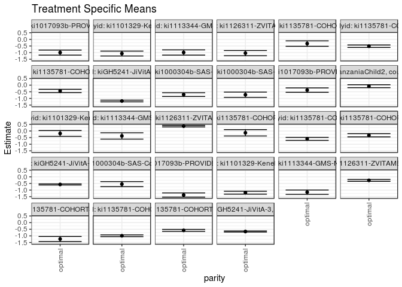

## Results Table

### Parameter: TSM

| agecat | studyid | country | intervention_level | baseline_level | estimate | ci_lower | ci_upper |
| --- | --- | --- | --- | --- | --- | --- | --- |
| Birth | ki1000304b-SAS-CompFeed | INDIA | optimal | observed | -0.5542439 | -0.7447156 | -0.3637722 |
| Birth | ki1017093b-PROVIDE | BANGLADESH | optimal | observed | -1.3738225 | -1.5328637 | -1.2147812 |
| Birth | ki1101329-Keneba | GAMBIA | optimal | observed | -1.1970488 | -1.3068929 | -1.0872048 |
| Birth | ki1113344-GMS-Nepal | NEPAL | optimal | observed | -1.1606554 | -1.3259478 | -0.9953630 |
| Birth | ki1126311-ZVITAMBO | ZIMBABWE | optimal | observed | -0.2695396 | -0.3413630 | -0.1977162 |
| Birth | ki1135781-COHORTS | GUATEMALA | optimal | observed | -1.2363381 | -1.4291400 | -1.0435361 |
| Birth | ki1135781-COHORTS | INDIA | optimal | observed | -0.9929339 | -1.0606575 | -0.9252103 |
| Birth | ki1135781-COHORTS | PHILIPPINES | optimal | observed | -0.5850585 | -0.6603363 | -0.5097806 |
| Birth | kiGH5241-JiVitA-3 | BANGLADESH | optimal | observed | -0.6708498 | -0.7123909 | -0.6293088 |
| 6 months | ki1000304b-SAS-CompFeed | INDIA | optimal | observed | -0.7130495 | -0.8540599 | -0.5720391 |
| 6 months | ki1000304b-SAS-FoodSuppl | INDIA | optimal | observed | -0.7219818 | -0.9198235 | -0.5241401 |
| 6 months | ki1017093b-PROVIDE | BANGLADESH | optimal | observed | -0.3727068 | -0.5399141 | -0.2054994 |
| 6 months | ki1066203-TanzaniaChild2 | TANZANIA, UNITED REPUBLIC OF | optimal | observed | -0.0782603 | -0.1893303 | 0.0328097 |
| 6 months | ki1101329-Keneba | GAMBIA | optimal | observed | -0.1855384 | -0.4039362 | 0.0328594 |
| 6 months | ki1113344-GMS-Nepal | NEPAL | optimal | observed | -0.3743893 | -0.6120644 | -0.1367141 |
| 6 months | ki1126311-ZVITAMBO | ZIMBABWE | optimal | observed | 0.3640580 | 0.3065047 | 0.4216113 |
| 6 months | ki1135781-COHORTS | GUATEMALA | optimal | observed | -0.1378711 | -0.3782581 | 0.1025159 |
| 6 months | ki1135781-COHORTS | INDIA | optimal | observed | -0.5946638 | -0.7087589 | -0.4805687 |
| 6 months | ki1135781-COHORTS | PHILIPPINES | optimal | observed | -0.3228926 | -0.4449962 | -0.2007890 |
| 6 months | kiGH5241-JiVitA-3 | BANGLADESH | optimal | observed | -0.5768951 | -0.6193237 | -0.5344665 |
| 24 months | ki1017093b-PROVIDE | BANGLADESH | optimal | observed | -0.9988395 | -1.1891286 | -0.8085505 |
| 24 months | ki1101329-Keneba | GAMBIA | optimal | observed | -1.0710962 | -1.2548424 | -0.8873501 |
| 24 months | ki1113344-GMS-Nepal | NEPAL | optimal | observed | -0.9931587 | -1.1903051 | -0.7960123 |
| 24 months | ki1126311-ZVITAMBO | ZIMBABWE | optimal | observed | -1.0400860 | -1.2372297 | -0.8429424 |
| 24 months | ki1135781-COHORTS | GUATEMALA | optimal | observed | -0.3204006 | -0.5261080 | -0.1146932 |
| 24 months | ki1135781-COHORTS | INDIA | optimal | observed | -0.5195646 | -0.6120487 | -0.4270806 |
| 24 months | ki1135781-COHORTS | PHILIPPINES | optimal | observed | -0.4375697 | -0.5609408 | -0.3141986 |
| 24 months | kiGH5241-JiVitA-3 | BANGLADESH | optimal | observed | -1.1954306 | -1.2600398 | -1.1308215 |

### Parameter: E(Y)

| agecat | studyid | country | intervention_level | baseline_level | estimate | ci_lower | ci_upper |
| --- | --- | --- | --- | --- | --- | --- | --- |
| Birth | ki1000304b-SAS-CompFeed | INDIA | observed | observed | -0.6700453 | -0.8474950 | -0.4925957 |
| Birth | ki1017093b-PROVIDE | BANGLADESH | observed | observed | -1.2984586 | -1.3752758 | -1.2216415 |
| Birth | ki1101329-Keneba | GAMBIA | observed | observed | -1.2037220 | -1.2694226 | -1.1380213 |
| Birth | ki1113344-GMS-Nepal | NEPAL | observed | observed | -1.1164431 | -1.2040134 | -1.0288728 |
| Birth | ki1126311-ZVITAMBO | ZIMBABWE | observed | observed | -0.5156349 | -0.5414936 | -0.4897762 |
| Birth | ki1135781-COHORTS | GUATEMALA | observed | observed | -1.0621429 | -1.1631387 | -0.9611471 |
| Birth | ki1135781-COHORTS | INDIA | observed | observed | -0.9498080 | -0.9874148 | -0.9122013 |
| Birth | ki1135781-COHORTS | PHILIPPINES | observed | observed | -0.7427251 | -0.7890855 | -0.6963647 |
| Birth | kiGH5241-JiVitA-3 | BANGLADESH | observed | observed | -0.7778272 | -0.7968313 | -0.7588232 |
| 6 months | ki1000304b-SAS-CompFeed | INDIA | observed | observed | -0.6657084 | -0.8024377 | -0.5289791 |
| 6 months | ki1000304b-SAS-FoodSuppl | INDIA | observed | observed | -1.0121579 | -1.1280429 | -0.8962729 |
| 6 months | ki1017093b-PROVIDE | BANGLADESH | observed | observed | -0.1990907 | -0.2817968 | -0.1163845 |
| 6 months | ki1066203-TanzaniaChild2 | TANZANIA, UNITED REPUBLIC OF | observed | observed | 0.0797179 | 0.0266621 | 0.1327737 |
| 6 months | ki1101329-Keneba | GAMBIA | observed | observed | -0.1873900 | -0.2456638 | -0.1291162 |
| 6 months | ki1113344-GMS-Nepal | NEPAL | observed | observed | -0.6038416 | -0.6899448 | -0.5177384 |
| 6 months | ki1126311-ZVITAMBO | ZIMBABWE | observed | observed | 0.3106432 | 0.2849661 | 0.3363203 |
| 6 months | ki1135781-COHORTS | GUATEMALA | observed | observed | 0.1940810 | 0.1226351 | 0.2655269 |
| 6 months | ki1135781-COHORTS | INDIA | observed | observed | -0.7068611 | -0.7417800 | -0.6719423 |
| 6 months | ki1135781-COHORTS | PHILIPPINES | observed | observed | -0.2938433 | -0.3352064 | -0.2524802 |
| 6 months | kiGH5241-JiVitA-3 | BANGLADESH | observed | observed | -0.5935161 | -0.6130518 | -0.5739805 |
| 24 months | ki1017093b-PROVIDE | BANGLADESH | observed | observed | -0.8928670 | -0.9755153 | -0.8102187 |
| 24 months | ki1101329-Keneba | GAMBIA | observed | observed | -0.7834078 | -0.8357743 | -0.7310414 |
| 24 months | ki1113344-GMS-Nepal | NEPAL | observed | observed | -1.1363107 | -1.2252817 | -1.0473398 |
| 24 months | ki1126311-ZVITAMBO | ZIMBABWE | observed | observed | -1.1817824 | -1.2809226 | -1.0826422 |
| 24 months | ki1135781-COHORTS | GUATEMALA | observed | observed | -0.2813755 | -0.3354674 | -0.2272835 |
| 24 months | ki1135781-COHORTS | INDIA | observed | observed | -0.6564729 | -0.6914450 | -0.6215007 |
| 24 months | ki1135781-COHORTS | PHILIPPINES | observed | observed | -0.6099592 | -0.6467541 | -0.5731643 |
| 24 months | kiGH5241-JiVitA-3 | BANGLADESH | observed | observed | -1.2978031 | -1.3210763 | -1.2745298 |

### Parameter: PAR

| agecat | studyid | country | intervention_level | baseline_level | estimate | ci_lower | ci_upper |
| --- | --- | --- | --- | --- | --- | --- | --- |
| Birth | ki1000304b-SAS-CompFeed | INDIA | optimal | observed | -0.1158014 | -0.2009034 | -0.0306994 |
| Birth | ki1017093b-PROVIDE | BANGLADESH | optimal | observed | 0.0753638 | -0.0674975 | 0.2182252 |
| Birth | ki1101329-Keneba | GAMBIA | optimal | observed | -0.0066731 | -0.0930816 | 0.0797353 |
| Birth | ki1113344-GMS-Nepal | NEPAL | optimal | observed | 0.0442124 | -0.1011230 | 0.1895477 |
| Birth | ki1126311-ZVITAMBO | ZIMBABWE | optimal | observed | -0.2460953 | -0.3147232 | -0.1774675 |
| Birth | ki1135781-COHORTS | GUATEMALA | optimal | observed | 0.1741952 | 0.0093363 | 0.3390541 |
| Birth | ki1135781-COHORTS | INDIA | optimal | observed | 0.0431259 | -0.0135518 | 0.0998036 |
| Birth | ki1135781-COHORTS | PHILIPPINES | optimal | observed | -0.1576666 | -0.2188775 | -0.0964557 |
| Birth | kiGH5241-JiVitA-3 | BANGLADESH | optimal | observed | -0.1069774 | -0.1462759 | -0.0676789 |
| 6 months | ki1000304b-SAS-CompFeed | INDIA | optimal | observed | 0.0473411 | -0.0506217 | 0.1453039 |
| 6 months | ki1000304b-SAS-FoodSuppl | INDIA | optimal | observed | -0.2901761 | -0.4854207 | -0.0949314 |
| 6 months | ki1017093b-PROVIDE | BANGLADESH | optimal | observed | 0.1736161 | 0.0275080 | 0.3197242 |
| 6 months | ki1066203-TanzaniaChild2 | TANZANIA, UNITED REPUBLIC OF | optimal | observed | 0.1579782 | 0.0605461 | 0.2554103 |
| 6 months | ki1101329-Keneba | GAMBIA | optimal | observed | -0.0018516 | -0.2158431 | 0.2121398 |
| 6 months | ki1113344-GMS-Nepal | NEPAL | optimal | observed | -0.2294523 | -0.4578872 | -0.0010175 |
| 6 months | ki1126311-ZVITAMBO | ZIMBABWE | optimal | observed | -0.0534148 | -0.1063001 | -0.0005294 |
| 6 months | ki1135781-COHORTS | GUATEMALA | optimal | observed | 0.3319521 | 0.0975757 | 0.5663285 |
| 6 months | ki1135781-COHORTS | INDIA | optimal | observed | -0.1121973 | -0.2206799 | -0.0037147 |
| 6 months | ki1135781-COHORTS | PHILIPPINES | optimal | observed | 0.0290493 | -0.0872001 | 0.1452987 |
| 6 months | kiGH5241-JiVitA-3 | BANGLADESH | optimal | observed | -0.0166210 | -0.0551498 | 0.0219077 |
| 24 months | ki1017093b-PROVIDE | BANGLADESH | optimal | observed | 0.1059725 | -0.0635520 | 0.2754970 |
| 24 months | ki1101329-Keneba | GAMBIA | optimal | observed | 0.2876884 | 0.1091425 | 0.4662343 |
| 24 months | ki1113344-GMS-Nepal | NEPAL | optimal | observed | -0.1431521 | -0.3279087 | 0.0416046 |
| 24 months | ki1126311-ZVITAMBO | ZIMBABWE | optimal | observed | -0.1416964 | -0.3149964 | 0.0316037 |
| 24 months | ki1135781-COHORTS | GUATEMALA | optimal | observed | 0.0390251 | -0.1562216 | 0.2342718 |
| 24 months | ki1135781-COHORTS | INDIA | optimal | observed | -0.1369082 | -0.2236194 | -0.0501970 |
| 24 months | ki1135781-COHORTS | PHILIPPINES | optimal | observed | -0.1723895 | -0.2899728 | -0.0548062 |
| 24 months | kiGH5241-JiVitA-3 | BANGLADESH | optimal | observed | -0.1023725 | -0.1632078 | -0.0415371 |